# EXNEX with count data and varying follow-up times

Author

Maximilian Rohde

Published

July 25, 2023

# Setup

```r
library(exnexstan)

library(tidyverse)
library(bayesplot)  # MCMC Diagnostic plots
library(tidybayes)  # Bayesian geoms for ggplot
library(patchwork)  # Plotting tools
library(gt)         # HTML tables
library(extrafont)  # Custom fonts in plots

# Set global ggplot theme
theme_set(cowplot::theme_cowplot(font_size=12,
                                 font_family = "Fira Sans"))
```

# Motivation

When monitoring for adverse events in a platform trial, it may be necessary to perform an interim analysis when follow-up is not complete for one or more of the trials. Due to the varying follow-up time for each patient when the interim analysis is conducted, it is not reasonable to compare the proportion of patients that experienced an adverse event (as would be done at the end of the trial).

A more principled approach is to weight the number of participants who experience an adverse events in a given trial by the total amount of patient follow-up. In this example, we use a Poisson model for the number of adverse events and an offset to account for the varying amount of follow-up time in each trial. In this model, once a participant experiences an adverse event, they would not contribute more follow-up time for that adverse event.

One limitation of this approach is that patient follow-up time is treated as exchangeable: the model treats one patient followed for 20 days identically to 5 patients followed for 4 days. Depending on how the adverse events occur over time, this may not be a reasonable assumption. Time-to-event analysis would overcome this limitation, but it is more difficult to incorporate the EXNEX structure because common models such as Kaplan-Meier and Cox proportional hazards are not parametric.

# Model

We can express the model as:

$$\begin{align*}
Z_{j} &\sim \operatorname{Bernoulli}(p_j) && \text{(Indicator variable of EX vs NEX)} \\
\theta_j &\sim \operatorname{Normal}(\text{mean} = \mu_{Z_{j}}, \, \text{sd} = \tau_{Z_{j}}) && \text{(Adverse event rate on log scale)} \\
\mu_0 &= \texttt{nex\_prior\_mean} && \text{(NEX mean)} \\
\tau_0 &= \texttt{nex\_prior\_sd} && \text{(NEX standard deviation)} \\
\mu_1 &\sim \operatorname{Normal}(\texttt{mu\_prior\_mean}, \, \texttt{mu\_prior\_sd}) && \text{(EX mean)} \\
\tau_1 &\sim \operatorname{Half-Normal}(\texttt{tau\_prior\_mean}, \, \texttt{tau\_prior\_sd}) && \text{(EX standard deviation)} \\
r_j &\sim \operatorname{Poisson}(\text{exp}(\theta_j + \log(t_j))) && \text{(Likelihood with offset)}
\end{align*}$$

We can also represent the model graphically as shown below.

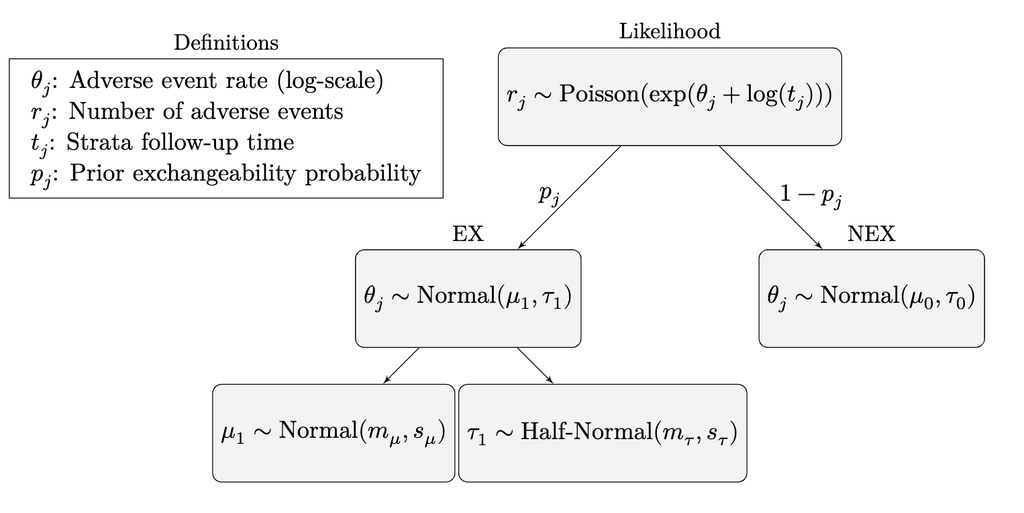

Illustration of the varying-time (Poisson) EXNEX model showing the connections between the likelihood, priors, and variables.

# Scenario

For an example scenario, we will create a platform trial comprised of 8 trials. We will assume that the EXNEX model is reasonable, so we generate two trials with a high event rate (non-exchangeable) and 6 with a low event rate (exchangeable). For simplicity, we will use the expected number of outcomes for each trial. The data for this scenario are shown in the below table.

[output not shown]

If we interpret the follow-up time as months of follow-up, then a rate of 0.1 would imply an average of 1 event every 10 months of participant follow-up.

## Generate scenario data

```r
# Follow-up times
t <- rep(c(10, 30, 60, 120), 2)

# True rates
rate <- c(0.8, 0.1, 0.1, 0.1, 0.1, 0.1, 0.1, 0.6)

# Number of observed events
r <- as.integer(t*rate)
```

```
[1]  8  3  6 12  1  3  6 72
```

# Statistical modeling

## Prior justification

EXNEX models can be sensitive to prior specification, so we must be careful to set appropriate priors.

### NEX

For the NEX prior, we calculate how the prior on the log-scale induces a prior for the Poisson rate parameter. In other words, we sample values from the normal prior on the log-rate parameter and then exponentiate to obtain the induced prior on the rate scale.

```r
nex_mean <- -1
nex_sd <- 1

# Generate samples from the prior
x <- exp(rnorm(1e5, nex_mean, nex_sd))
```

This prior allocates about 80% of the prior probability to rate parameters below 1.

[figure not shown]

### EX

For the exchangeable priors (mu and tau), we compute the induced prior for the rate parameter by first sampling mu and tau, and then drawing a theta from that distribution. We repeat the process as in the NEX case and observe that these parameters induce a similar prior to the NEX prior.

```r
mu_mean <- -1
mu_sd <- 1
tau_mean <- 0
tau_sd <- 0.5
```

```r
# Draw a sample from the EX prior by first drawing from the hierarchical parameters
# then drawing theta conditional on them
draw <- function(mu_mean,
                 mu_sd,
                 tau_mean,
                 tau_sd){
  # Draw mu
  mu <- rnorm(n=1,
              mean=mu_mean,
              sd=mu_sd)
  # Draw tau
  tau <- rnorm(n=1,
               mean=tau_mean,
               sd=tau_sd) |> abs()
  # Draw theta conditional on mu and tau
  theta <- rnorm(n=1,
                 mean=mu,
                 sd=tau)

  return(exp(theta))
}

x <- map_dbl(1:1e5, ~draw(mu_mean, mu_sd, tau_mean, tau_sd))
```

[figure not shown]

## Model fitting

We now fit the EX, EXNEX, and NEX models to these data to compare how they perform. To fit these models with `exnexstan`, use the `fit_exnex_varying_time()` function. The data are the follow-up time for each trial (`t`) and the number of events in each trial (`r`).

### Parameters

```r
# Set values for prior parameters
mu_prior_mean <- -1
mu_prior_sd <- 1
tau_lower_bound <- 0
tau_prior_mean <- 0
tau_prior_sd <- 0.5
nex_prior_mean <- -1
nex_prior_sd <- 1
```

### EX

```r
ex <-
  exnexstan::fit_exnex_varying_time(
    t = t,
    r = r,
    p_exch = rep(1, 8),
    mu_prior_mean = mu_prior_mean,
    mu_prior_sd = mu_prior_sd,
    tau_lower_bound = tau_lower_bound,
    tau_prior_mean = tau_prior_mean,
    tau_prior_sd = tau_prior_sd,
    nex_prior_mean = nex_prior_mean,
    nex_prior_sd = nex_prior_sd,
    adapt_delta = 0.99
  )
```

#### Summary

EX Analysis Results

| Strata Response Probability | Posterior Mean | Posterior Median | Posterior SD | 0.05 Quantile | 0.95 Quantile | Rhat |
| --- | --- | --- | --- | --- | --- | --- |
| rate[1] | 0.59991180669 | 0.5659825 | 0.233947725372253 | 0.2807566 | 1.0352335 | 1.00019745063427 |
| rate[2] | 0.125995493625 | 0.117607 | 0.0549731779895395 | 0.051926585 | 0.2270138 | 1.00006650691073 |
| rate[3] | 0.115643857815 | 0.1109525 | 0.0400331803366151 | 0.05888227 | 0.18850105 | 1.0003109900448 |
| rate[4] | 0.10843437408 | 0.1059625 | 0.0287974616901893 | 0.065867455 | 0.15959945 | 1.00017761308848 |
| rate[5] | 0.152652730638 | 0.135193 | 0.0888715215245216 | 0.044242555 | 0.3201347 | 1.00023566710679 |
| rate[6] | 0.12597553139 | 0.117796 | 0.0549577328364145 | 0.05126398 | 0.2277681 | 1.0000920833534 |
| rate[7] | 0.11508728054 | 0.1106135 | 0.0401164564989826 | 0.05833405 | 0.1885261 | 1.00001484887964 |
| rate[8] | 0.58130608 | 0.578412 | 0.0689988857655009 | 0.4729812 | 0.6990078 | 0.999940148229008 |

### NEX

```r
nex <-
  exnexstan::fit_exnex_varying_time(
    t = t,
    r = r,
    p_exch = rep(0, 8),
    mu_prior_mean = mu_prior_mean,
    mu_prior_sd = mu_prior_sd,
    tau_lower_bound = tau_lower_bound,
    tau_prior_mean = tau_prior_mean,
    tau_prior_sd = tau_prior_sd,
    nex_prior_mean = nex_prior_mean,
    nex_prior_sd = nex_prior_sd,
    adapt_delta = 0.99
  )
```

#### Summary

NEX Analysis Results

| Strata Response Probability | Posterior Mean | Posterior Median | Posterior SD | 0.05 Quantile | 0.95 Quantile | Rhat |
| --- | --- | --- | --- | --- | --- | --- |
| rate[1] | 0.7371602805 | 0.7051535 | 0.257499221801674 | 0.37707365 | 1.1991915 | 1.00008521554062 |
| rate[2] | 0.136809012665 | 0.127819 | 0.0603185647773184 | 0.055833155 | 0.2486308 | 1.00031226931724 |
| rate[3] | 0.11939748979 | 0.114201 | 0.0419202111340123 | 0.060116725 | 0.1958566 | 1.00065665240247 |
| rate[4] | 0.11047410071 | 0.107805 | 0.0290673197943122 | 0.067608375 | 0.1620603 | 1.00012810349468 |
| rate[5] | 0.18579857601 | 0.161621 | 0.111972185277499 | 0.05357603 | 0.40068365 | 1.0001381517234 |
| rate[6] | 0.136189967635 | 0.1265215 | 0.0611314563043937 | 0.05555605 | 0.25191345 | 1.00011943240363 |
| rate[7] | 0.11967926659 | 0.1147455 | 0.0422052324972668 | 0.06028072 | 0.1969125 | 1.00004427707716 |
| rate[8] | 0.59567676325 | 0.593021 | 0.0701636943736296 | 0.48540795 | 0.71687245 | 1.00013289683326 |

### EXNEX

```r
exnex <-
  exnexstan::fit_exnex_varying_time(
    t = t,
    r = r,
    p_exch = rep(0.5, 8),
    mu_prior_mean = mu_prior_mean,
    mu_prior_sd = mu_prior_sd,
    tau_lower_bound = tau_lower_bound,
    tau_prior_mean = tau_prior_mean,
    tau_prior_sd = tau_prior_sd,
    nex_prior_mean = nex_prior_mean,
    nex_prior_sd = nex_prior_sd,
    adapt_delta = 0.99
  )
```

#### Summary

EXNEX Analysis Results

| Strata Response Probability | Posterior Mean | Posterior Median | Posterior SD | 0.05 Quantile | 0.95 Quantile | Rhat |
| --- | --- | --- | --- | --- | --- | --- |
| rate[1] | 0.7352031915 | 0.7065235 | 0.254049463857628 | 0.3752058 | 1.195741 | 1.00068406220254 |
| rate[2] | 0.1139434516 | 0.1063685 | 0.0421955831040767 | 0.061577445 | 0.19299065 | 1.00031231245355 |
| rate[3] | 0.107905237625 | 0.104431 | 0.0309111859539657 | 0.064831975 | 0.1641982 | 1.00040821217445 |
| rate[4] | 0.10548268228 | 0.103516 | 0.024134475281423 | 0.069836335 | 0.1485031 | 1.00060934537352 |
| rate[5] | 0.1328854831345 | 0.111543 | 0.077814687033369 | 0.057483335 | 0.28944865 | 1.00015472536779 |
| rate[6] | 0.11403932221 | 0.106464 | 0.0420359663423863 | 0.06187278 | 0.1928376 | 1.00067866461179 |
| rate[7] | 0.108261089195 | 0.10454 | 0.0313064974363723 | 0.064664675 | 0.16439835 | 1.00034135665631 |
| rate[8] | 0.59693314835 | 0.5945525 | 0.0701664843360357 | 0.4867354 | 0.7171672 | 1.00006997157888 |

## Plotting

For each of the methods and each strata, we plot the posterior median along with the 50% and 95% credible intervals. The number of events and total follow-up time are shown for each strata.

[figure not shown]